# SMMS Sternite Dataset Analysis

Gregory K. Ross

University of Florida  
gkross@ufl.edu

# 1 Introduction

This analysis was performed by the University of Florida - Florida Medical Entomology Laboratory, 200 9th Street SE, Vero Becah FL, 32962. This analysis is done in a reproducible research manner. All Tables, Figures and Statistical Analyses were created in the open source software package R.

**Date:** 10/26/2016

**Version:** 2.0

# 2 Data

A copy of this data analysis (PDF) may be downloaded [here](https://gatorbox.rc.ufl.edu/index.php/s/tYayMuuQ8iowUd8).

A copy of the original data (XLSX) may be downloaded [here](https://gatorbox.rc.ufl.edu/index.php/s/aStOBibUNnTcPDJ).

A copy of the cleaned data (CSV) used for the analysis may be downloaded [here](https://gatorbox.rc.ufl.edu/index.php/s/iMHCgooLtCEpN6Y).

**Notes:** The original data had 1244 records. One (1) record was modified due to a data entry error. All values of 0.02 or 0.05 were changed to 0.10 for categorical data analysis.

# 3 Analysis

## 3.1 AEG/ALB Analysis (Both Species)

### 3.1.1 AEG/ALB Data Summary

Table 1. Summary of Sternite Dataset

| SCUTUM | STERGUM |
| --- | --- |
| Min. :0.0000 | Min. :0.0000 |
| 1st Qu.:0.1000 | 1st Qu.:0.8000 |
| Median :0.2000 | Median :1.0000 |
| Mean :0.3372 | Mean :0.8665 |
| 3rd Qu.:0.6000 | 3rd Qu.:1.0000 |
| Max. :1.0000 | Max. :1.0000 |

### 3.1.2 AEG/ALB Data Description

Table 2. Description of Sternite Dataset

|  | vars | n | mean | sd | median | trimmed | mad | min | max | range | skew | kurtosis | se |
| --- | --- | --- | --- | --- | --- | --- | --- | --- | --- | --- | --- | --- | --- |
| **SCUTUM** | 1 | 1241 | 0.3372 | 0.3283 | 0.2 | 0.3015 | 0.2965 | 0 | 1 | 1 | 0.7975 | -0.8095 | 0.00932 |
| **STERGUM** | 2 | 1241 | 0.8665 | 0.226 | 1 | 0.9224 | 0 | 0 | 1 | 1 | -2.042 | 3.381 | 0.006415 |

### 3.1.3 AEG/ALB Data Dispersion

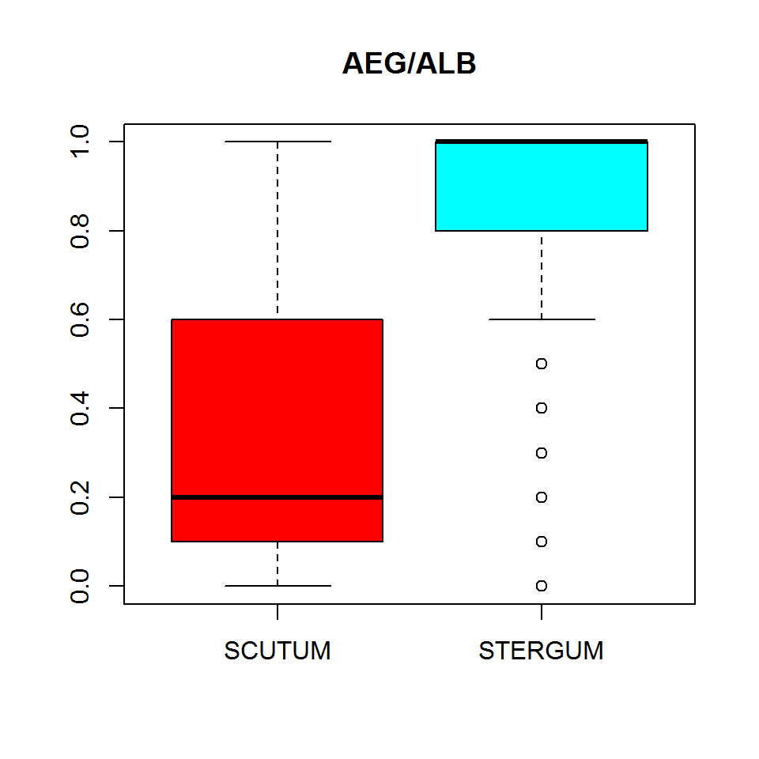

Figure 1.

### 3.1.4 AEG/ALB Data Distribution

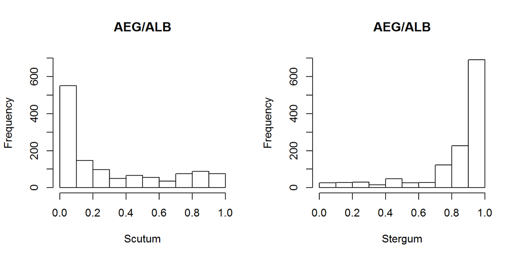

Figure 2.

### 3.1.5 AEG/ALB Hexbin of Scutum vs Stergum

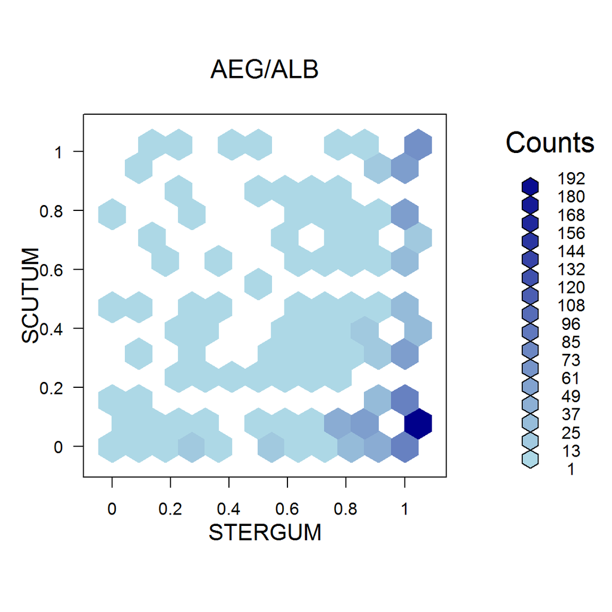

Figure 3.

### 3.1.6 AEG/ALB Analysis Discussion

When looking at both species as a collective dataset, the scutum and stergum data appear to be heavily skewed, though in opposite directions. Figure 3 indicates that when the stergum is skewed in the direction of 100% coverage and the scutum is skewed in the direction of 0% coverage.

## 3.2 AEG Analysis

### 3.2.1 AEG Data Summary

Table 3. Summary of AEG Dataset

| SCUTUM | STERGUM |
| --- | --- |
| Min. :0.0000 | Min. :0.0000 |
| 1st Qu.:0.4000 | 1st Qu.:0.9000 |
| Median :0.6000 | Median :1.0000 |
| Mean :0.6026 | Mean :0.9132 |
| 3rd Qu.:0.9000 | 3rd Qu.:1.0000 |
| Max. :1.0000 | Max. :1.0000 |

### 3.2.2 AEG Data Description

Table 4. Description of AEG Dataset

|  | vars | n | mean | sd | median | trimmed | mad | min | max | range | skew | kurtosis | se |
| --- | --- | --- | --- | --- | --- | --- | --- | --- | --- | --- | --- | --- | --- |
| **SCUTUM** | 1 | 227 | 0.6026 | 0.2969 | 0.6 | 0.6224 | 0.2965 | 0 | 1 | 1 | -0.4569 | -0.8901 | 0.0197 |
| **STERGUM** | 2 | 227 | 0.9132 | 0.1735 | 1 | 0.9552 | 0 | 0 | 1 | 1 | -3.094 | 10.62 | 0.01151 |

### 3.2.3 AEG Data Frequency Counts

Table 5. AEG Frequencies

|  | AEG$SCUTUM | 0 | 0.1 | 0.2 | 0.3 | 0.4 | 0.5 | 0.6 | 0.7 | 0.8 | 0.9 | 1 |
| --- | --- | --- | --- | --- | --- | --- | --- | --- | --- | --- | --- | --- |
| AEG$STERGUM |  |  |  |  |  |  |  |  |  |  |  |  |
| 0 |  | 1 | 0 | 0 | 0 | 0 | 1 | 0 | 0 | 0 | 0 | 0 |
| 0.1 |  | 0 | 0 | 0 | 1 | 0 | 0 | 0 | 0 | 0 | 0 | 0 |
| 0.2 |  | 1 | 0 | 0 | 0 | 0 | 0 | 0 | 0 | 0 | 0 | 0 |
| 0.3 |  | 2 | 0 | 0 | 0 | 1 | 0 | 0 | 0 | 1 | 0 | 0 |
| 0.5 |  | 0 | 1 | 0 | 0 | 0 | 1 | 0 | 0 | 0 | 1 | 0 |
| 0.6 |  | 0 | 0 | 0 | 0 | 1 | 1 | 1 | 0 | 1 | 0 | 0 |
| 0.7 |  | 1 | 0 | 0 | 1 | 1 | 0 | 1 | 0 | 0 | 1 | 0 |
| 0.8 |  | 3 | 3 | 1 | 1 | 1 | 3 | 1 | 1 | 4 | 1 | 1 |
| 0.9 |  | 1 | 0 | 4 | 6 | 3 | 6 | 4 | 5 | 4 | 11 | 2 |
| 1 |  | 4 | 6 | 4 | 11 | 11 | 10 | 16 | 14 | 22 | 22 | 21 |

### 3.2.4 AEG Data Dispersion

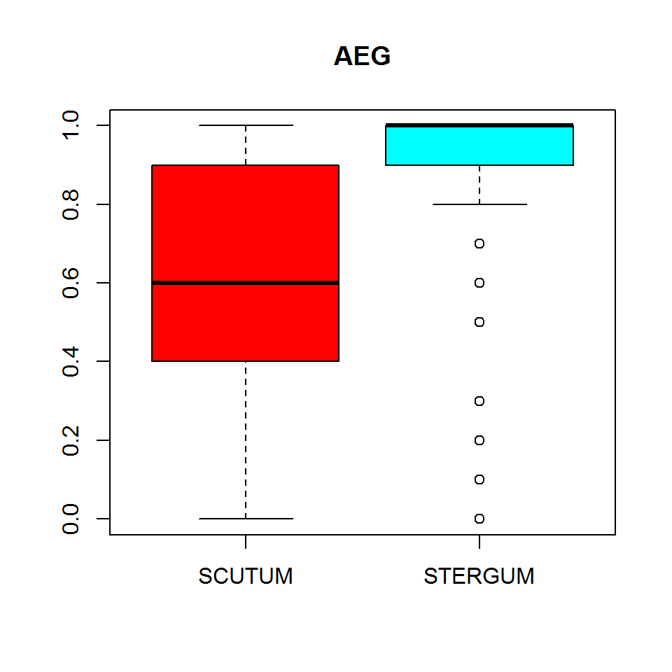

Figure 6.

### 3.2.5 AEG Data Distribution

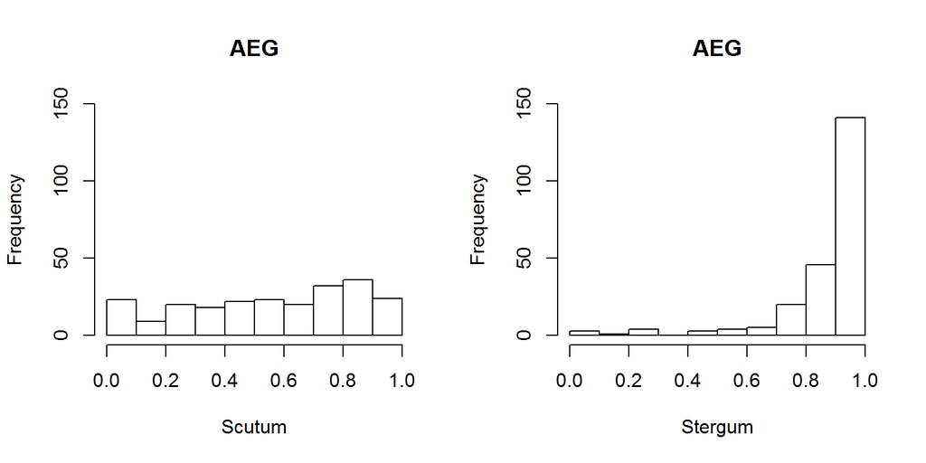

Figure 7.

### 3.2.6 AEG Data Chi-Square Test for Independence

Table 6. AEG Chi-Square Test for Independence

| Test statistic | df | P value |
| --- | --- | --- |
| 111.2 | 90 | 0.06401 |

### 3.2.7 AEG Data Mosaic Plot

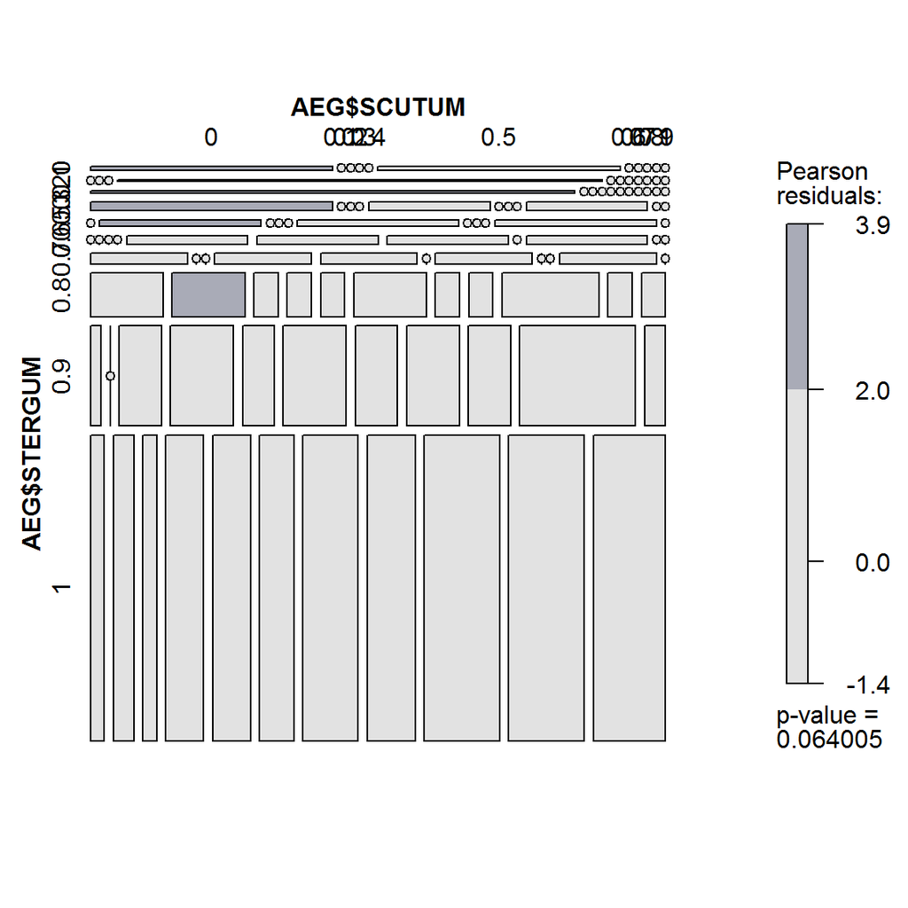

Figure 8.

### 3.2.8 AEG Analysis Discussion

When looking at the AEG species, the stergum dataset appears to be heavily skewed while the scutum appears to be closer to normal. Table 6 and Figure 8 indicate that there are no significant differences between AEG scutum and stregum coverages at the 0.05 level.

## 3.3 ALB Analysis

### 3.3.1 ALB Data Summary

Table 7. Summary of ALB Dataset

| SCUTUM | STERGUM |
| --- | --- |
| Min. :0.0000 | Min. :0.000 |
| 1st Qu.:0.1000 | 1st Qu.:0.800 |
| Median :0.1000 | Median :1.000 |
| Mean :0.2778 | Mean :0.856 |
| 3rd Qu.:0.4000 | 3rd Qu.:1.000 |
| Max. :1.0000 | Max. :1.000 |

### 3.3.2 ALB Data Description

Table 8. Description of ALB Dataset (continued below)

|  | vars | n | mean | sd | median | trimmed | mad | min |
| --- | --- | --- | --- | --- | --- | --- | --- | --- |
| **SCUTUM** | 1 | 1014 | 0.2778 | 0.3049 | 0.1 | 0.2287 | 0.1483 | 0 |
| **STERGUM** | 2 | 1014 | 0.856 | 0.2349 | 1 | 0.9121 | 0 | 0 |

|  | max | range | skew | kurtosis | se |
| --- | --- | --- | --- | --- | --- |
| **SCUTUM** | 1 | 1 | 1.205 | 0.1296 | 0.009575 |
| **STERGUM** | 1 | 1 | -1.886 | 2.623 | 0.007378 |

### 3.3.3 ALB Data Frequency Counts

Table 9. ALB Frequencies

|  | ALB$SCUTUM | 0 | 0.1 | 0.2 | 0.3 | 0.4 | 0.5 | 0.6 | 0.7 | 0.8 | 0.9 | 1 |
| --- | --- | --- | --- | --- | --- | --- | --- | --- | --- | --- | --- | --- |
| ALB$STERGUM |  |  |  |  |  |  |  |  |  |  |  |  |
| 0 |  | 1 | 1 | 1 | 0 | 0 | 0 | 0 | 0 | 1 | 0 | 0 |
| 0.1 |  | 5 | 4 | 4 | 0 | 0 | 1 | 0 | 1 | 0 | 2 | 2 |
| 0.2 |  | 10 | 3 | 8 | 0 | 1 | 0 | 1 | 0 | 0 | 2 | 1 |
| 0.3 |  | 12 | 7 | 3 | 2 | 0 | 1 | 0 | 0 | 1 | 0 | 0 |
| 0.4 |  | 9 | 0 | 1 | 0 | 0 | 1 | 3 | 0 | 0 | 0 | 1 |
| 0.5 |  | 15 | 9 | 7 | 4 | 0 | 5 | 1 | 0 | 0 | 2 | 2 |
| 0.6 |  | 4 | 10 | 3 | 1 | 0 | 0 | 1 | 1 | 1 | 1 | 0 |
| 0.7 |  | 6 | 10 | 3 | 0 | 1 | 2 | 0 | 0 | 1 | 0 | 0 |
| 0.8 |  | 28 | 39 | 9 | 8 | 4 | 4 | 2 | 2 | 5 | 2 | 0 |
| 0.9 |  | 39 | 60 | 21 | 15 | 11 | 5 | 7 | 3 | 6 | 13 | 1 |
| 1 |  | 70 | 186 | 78 | 48 | 14 | 25 | 17 | 9 | 29 | 30 | 44 |

### 3.3.4 ALB Data Dispersion

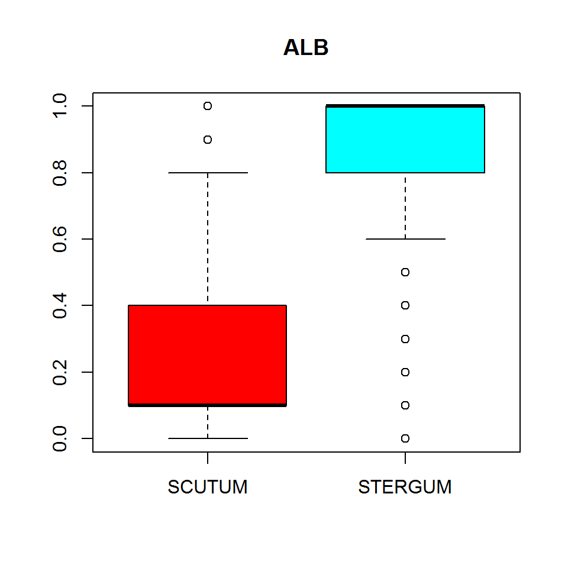

Figure 9.

### 3.3.5 ALB Data Distribution

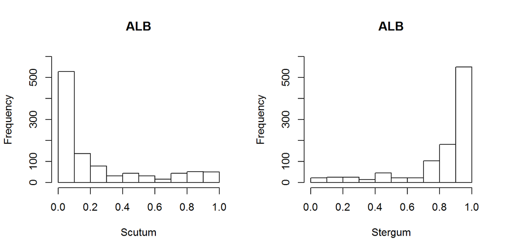

Figure 10.

### 3.3.6 ALB Data Chi-Square Test for Independence

Table 10. ALB Chi-Square Test for Independence

| Test statistic | df | P value |
| --- | --- | --- |
| 168.8 | 100 | 2.073e-05 * * * |

### 3.3.7 ALB Data Mosaic Plot

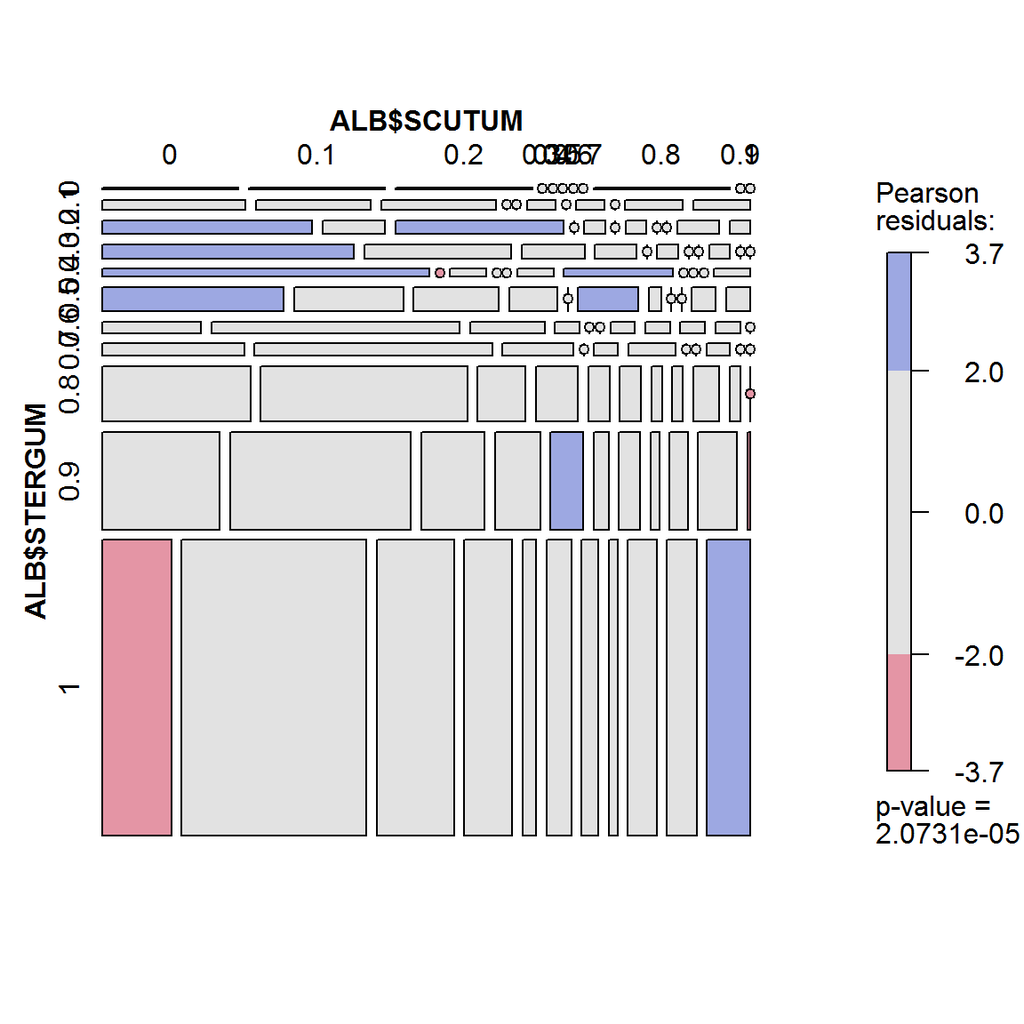

Figure 11.

### 3.3.8 ALB Analysis Discussion

When looking at the ALB species, the scutum and stergum datasets appear to be heavily skewed, though in opposite directions. Table 10 and Figure 11 indicate that there are significant differences between AEG scutum and stregum coverages at the 0.05 and 0.01 level.

## 3.4 Between Species Data (AEG and ALB)

### 3.4.1 Between Species Data Frequency Counts

Table 11. Stergum Frequencies

|  | STERGUM | 0 | 0.1 | 0.2 | 0.3 | 0.4 | 0.5 | 0.6 | 0.7 | 0.8 | 0.9 | 1 |
| --- | --- | --- | --- | --- | --- | --- | --- | --- | --- | --- | --- | --- |
| SPECIES |  |  |  |  |  |  |  |  |  |  |  |  |
| AEG |  | 2 | 1 | 1 | 4 | 0 | 3 | 4 | 5 | 20 | 46 | 141 |
| ALB |  | 4 | 19 | 26 | 26 | 15 | 45 | 22 | 23 | 103 | 181 | 550 |

Table 12. Scutum Frequencies

|  | SCUTUM | 0 | 0.1 | 0.2 | 0.3 | 0.4 | 0.5 | 0.6 | 0.7 | 0.8 | 0.9 | 1 |
| --- | --- | --- | --- | --- | --- | --- | --- | --- | --- | --- | --- | --- |
| SPECIES |  |  |  |  |  |  |  |  |  |  |  |  |
| AEG |  | 13 | 10 | 9 | 20 | 18 | 22 | 23 | 20 | 32 | 36 | 24 |
| ALB |  | 199 | 329 | 138 | 78 | 31 | 44 | 32 | 16 | 44 | 52 | 51 |

### 3.4.2 Between Species Data Scutum Distribution

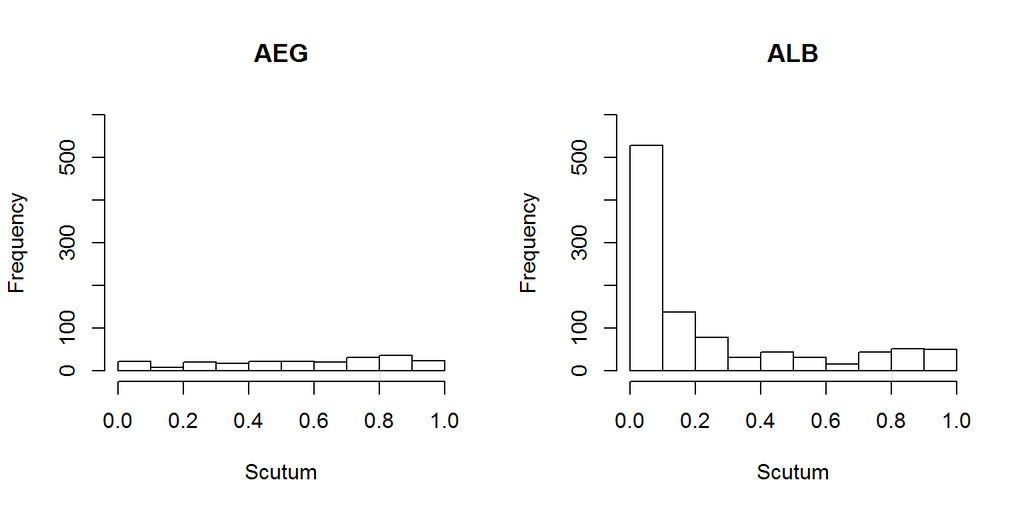

Figure 12.

### 3.4.3 Between Species Data Scutum Distribution - Stacked

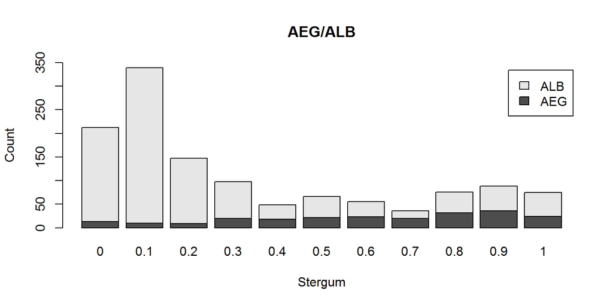

Figure 13.

### 3.4.4 Between Species Data Scutum Spine Plot

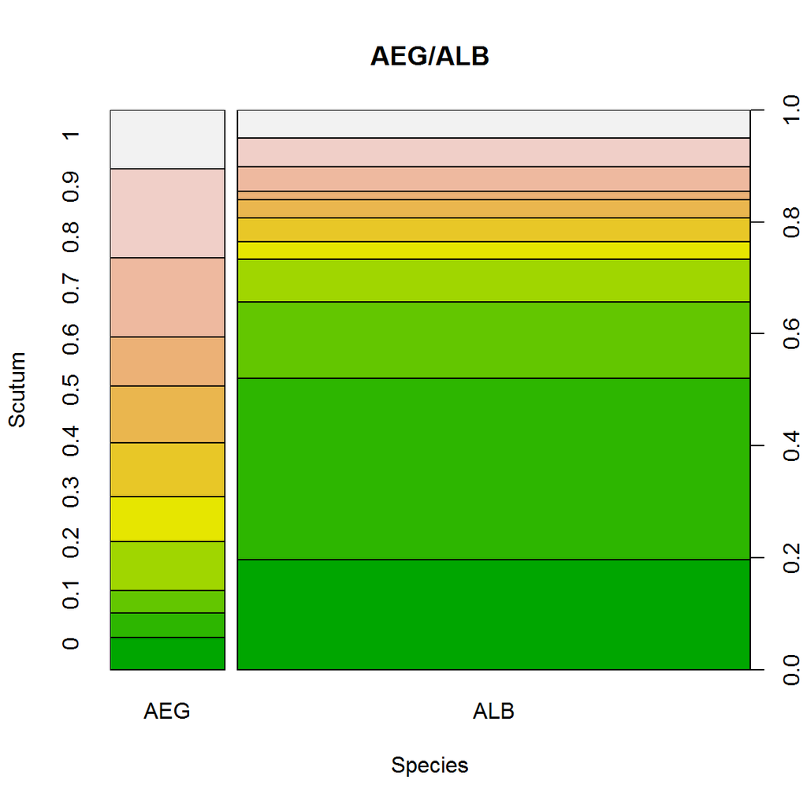

Figure 14.

### 3.4.5 Between Species Data Scutum Chi-Square Test for Independence

Table 13. Between Species Scutum Chi-Square Test for Independence

| Test statistic | df | P value |
| --- | --- | --- |
| 232.6 | 10 | 2.492e-44 * * * |

### 3.4.6 Between Species Data Scutum Mosaic Plot

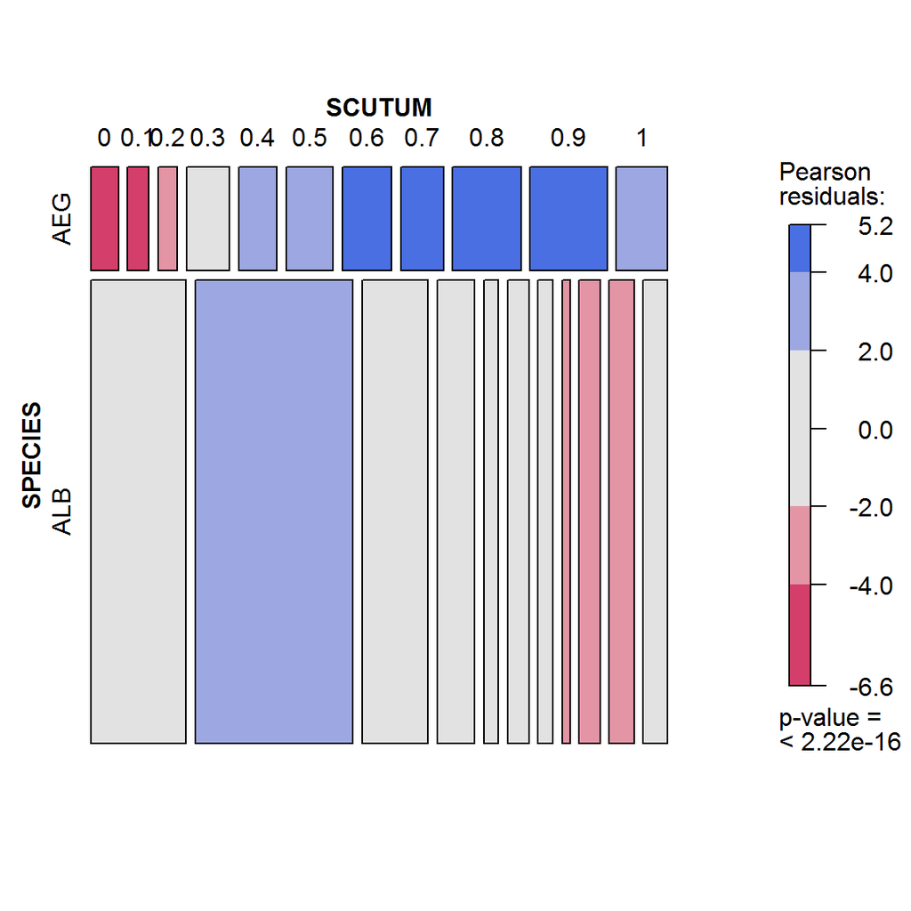

Figure 15.

### 3.4.7 Between Species Data Stergum Distribution

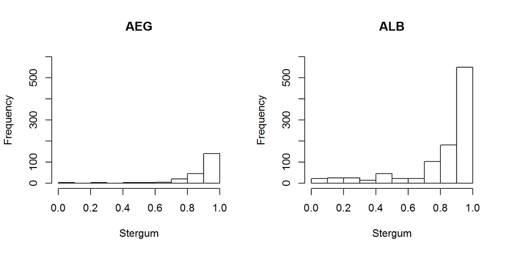

Figure 16.

### 3.4.8 Between Species Data Stergum Distribution - Stacked

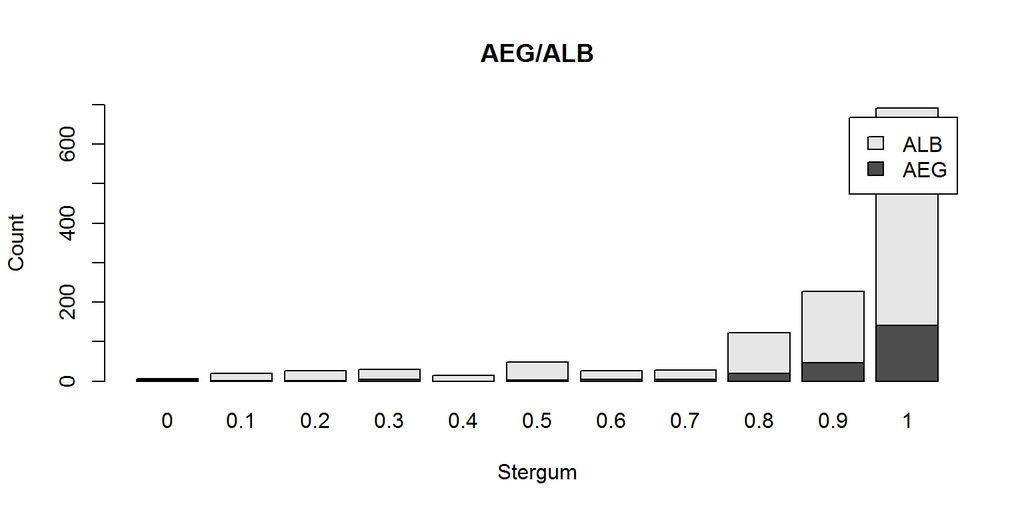

Figure 17.

### 3.4.9 Between Species Data Stergum Spine Plot

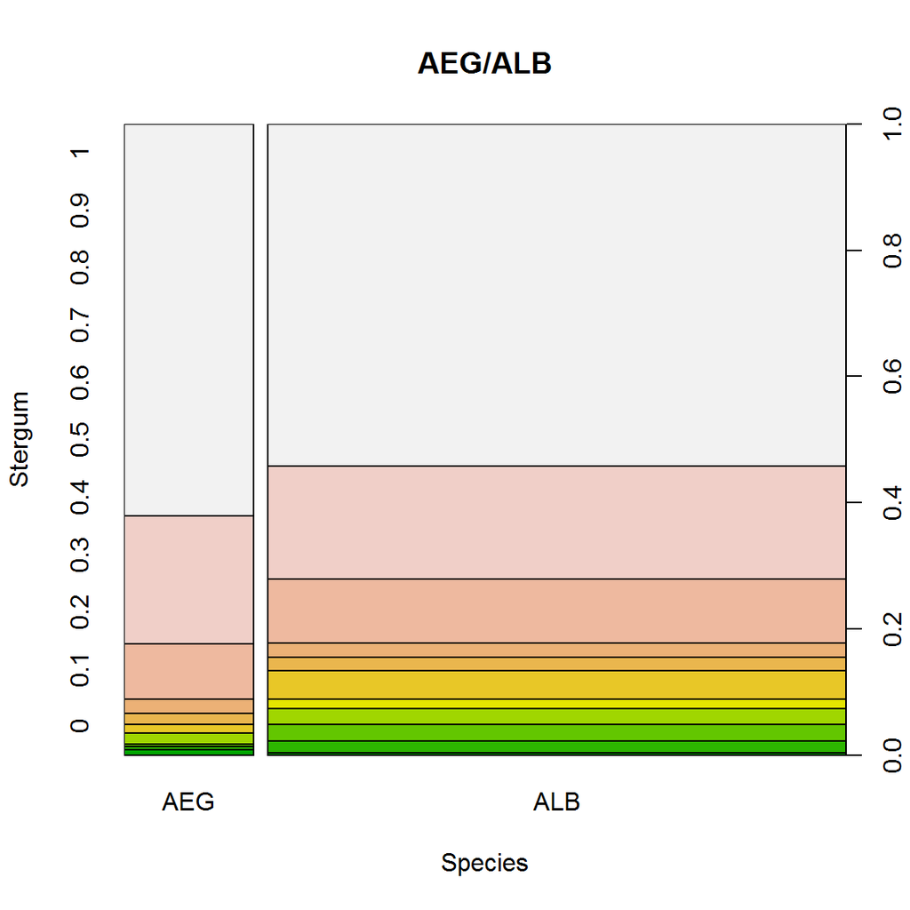

Figure 18.

### 3.4.10 Between Species Data Stergum Chi-Square Test for Independence

Table 14. Between Species Stergum Chi-Square Test for Independence

| Test statistic | df | P value |
| --- | --- | --- |
| 18.77 | 10 | 0.04326 * |

### 3.4.11 Between Species Data Stergum Mosaic Plot

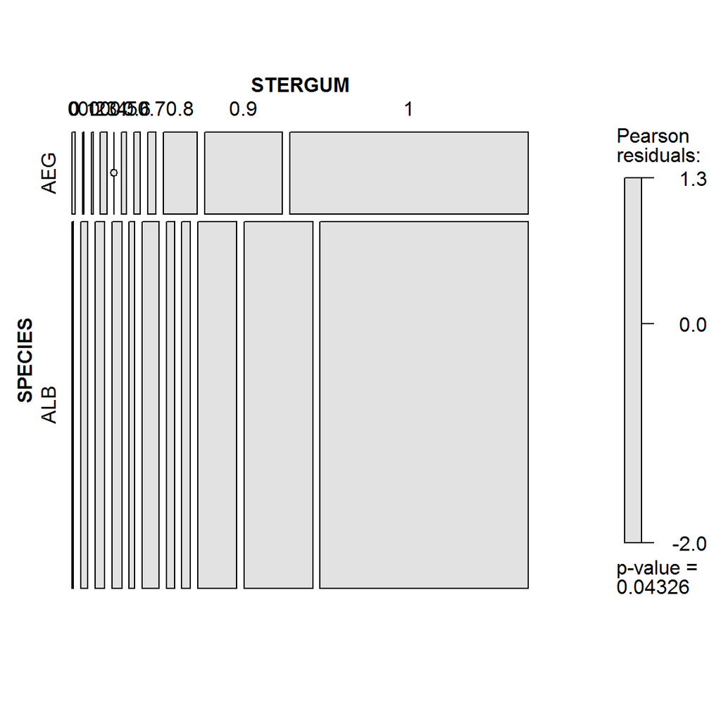

Figure 19.

### 3.4.12 Between Species Analysis Discussion

When looking between the AEG and ALB species, the stergum datasets appear to be heavily skewed in the same direction while the scutum datstets appear to be different between species. **Table 13** indicates that there are *significant differences between AEG and ALB species scutum coverages* at the 0.05 and 0.01 level. **Figure 15** shows that range of 0.6 - 0.9 scutum coverages for AEG had *significantly more* values than expected and the range of 0.0 - 0.1 scutum coverages for AEG had *significantly less* values than expected. **Figure 15** also indicates that for ALB the range of 0.7 - 0.9 scutum coverages had *less* values than expected **Table 14** indicates that there are *significant differences between AEG and ALB species stergum coverages* at the 0.05 level. **Figure 19** shows that no coverages for either species had *significantly* more or less values than expected.